# Mixture Effect Index

Jared Flater

12/2/2020

```r
library(phyloseq)
library(readr)
library(tidyverse)
library(Rmisc)
library(ggpubr)
```

# Mixture Effect Index

$MEI_{otu X}=\frac{A_{observed}-A_{expected}}{A_{expected}}= \frac{A_{c + a}-\left ( \frac{A_{a}+A_{c}}{2} \right )}{\frac{A_{a}+A_{c}}{2}}$

Aobserved = OTU X abundance of what you observed in the mixed treatment (i.e. Ac+a) Aexpected = OTU X abundance of what you expect to find in the mixed treatment based on adding both INDIVUAL effects together and dividing by two. Ac+a = abundance of OTU X in Compost+Alfalfa amendment Ac = abundance of OTU X in Compost ONLY amendment Aa = abundance of OTU X in Alfalfa ONLY amendment

MEI >> 1 for an OTU = synergistic effect of adding Compost & Alfalfa together

MEI << 1 for an OTU = antagonistic effect of adding Compost & Alfalfa together

It would be neat to see what bacteria species/clades have strong positive, or negative, MEI’s.

It would be cool to look at this MEI through time (for inorganic N and MBC too). I think you could make a PCA or nmds of MEI scores too and look at how it relates to other things you measured (nitrate, pH, etc…)!

For more information on MEI see… Wardle, D. A., Bonner, K. I., & Nicholson, K. S. (1997). Biodiversity and plant litter: experimental evidence which does not support the view that enhanced species richness improves ecosystem function. Oikos, 247-258. Meier, C. L., & Bowman, W. D. (2010). Chemical composition and diversity influence non-additive effects of litter mixtures on soil carbon and nitrogen cycling: implications for plant species loss. Soil Biology and Biochemistry, 42(9), 1447-1454. McDaniel, M. D., Grandy, A. S., Tiemann, L. K., & Weintraub, M. N. (2016). Eleven years of crop diversification alters decomposition dynamics of litter mixtures incubated with soil. Ecosphere, 7(8), e01426.

## Incubation data and taxonomy

```r
### Scale color for phyla, consistent phyla colors across plots
#Function to make all phyla colors consistent
phylalist <- data.frame(tax_table(inc),row.names = NULL) %>%
  select(Phylum) %>%
  unique()
phylalist$Phylum <- as.character(phylalist$Phylum)
phylalist$Phylum[is.na(phylalist$Phylum)] <- "Unclassified"
# this package will generate a palette based on number and desired colors
library(colorspace)
colors <- sequential_hcl(n_distinct(phylalist), palette = "viridis") %>%
  sample() %>%
  setNames(phylalist$Phylum)
```

# MEI function

```r
MEI <- function(phy, taxa){
  OTU <- taxa
  Aca <- subset_samples(phy, treatment %in% "Mix") %>%
    transform_sample_counts(function(x) {x/sum(x)}) %>%
    prune_taxa(taxa = OTU) %>%
    sample_sums() %>%
    mean()
  Aa <- subset_samples(phy, treatment %in% "Alfalfa") %>%
    transform_sample_counts(function(x) {x/sum(x)}) %>%
    prune_taxa(taxa = OTU) %>%
    sample_sums() %>%
    mean()
  Ac <- subset_samples(phy, treatment %in% "Compost") %>%
    transform_sample_counts(function(x) {x/sum(x)}) %>%
    prune_taxa(taxa = OTU) %>%
    sample_sums() %>%
    mean()
  MEI <- (Aca - ((Aa + Ac)/2))/((Aa + Ac)/2)
  return(MEI)
}
```

```r
resp_table <- read_csv("../Data/resp_table.csv")
```

```r
MEI_resonder <- resp_table$X1 %>%
  map( ~ MEI(inc, taxa = .))

resp_table$MEI <- unlist(MEI_resonder)
```

```r
Taxa_responders <- prune_taxa(resp_table$X1, inc) %>%
  tax_table()
```

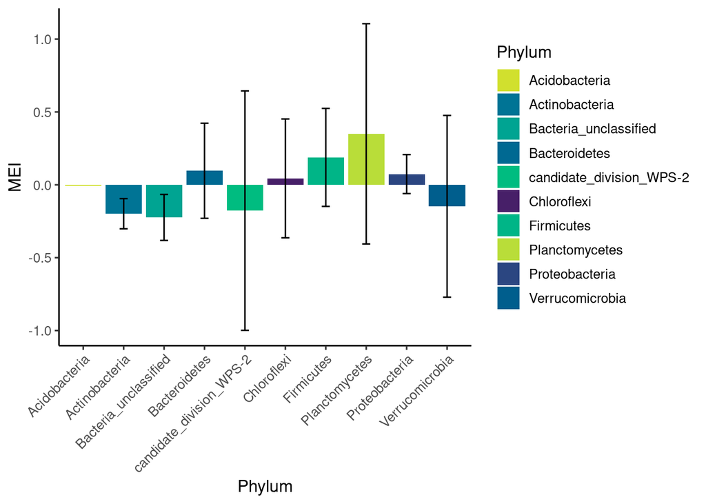

```r
resp_table <- cbind(resp_table, as.data.frame(Taxa_responders))
summarySE(resp_table, measurevar = "MEI", groupvars = "Phylum") %>%
  ggplot(aes(x = Phylum, y = MEI, fill = Phylum)) +
  geom_bar(position=position_dodge(), stat="identity") +
  geom_errorbar(aes(ymin = MEI - ci, ymax = MEI + ci),
                width=.2, position=position_dodge(.9)) +
  theme(axis.text.x = element_text(angle = 45, hjust = 1)) +
  scale_color_manual(aesthetics = "fill", values = colors) +
  theme_classic2() +
  rotate_x_text(45)
```

# All responding OTUs

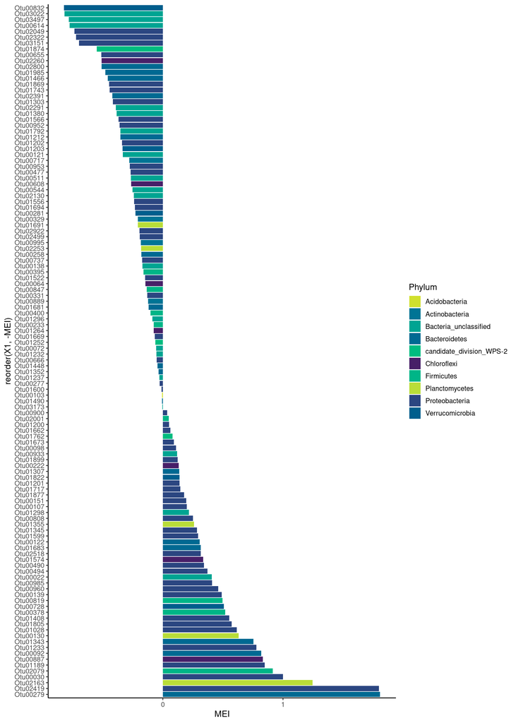

```r
ggplot(resp_table, aes(x = reorder(X1, -MEI), y = MEI, fill = Phylum)) +
  geom_bar(stat = "identity") + coord_flip() +
  scale_color_manual(aesthetics = "fill", values = colors) +
  theme_classic2()
```

# Ammendment responding OTUs

```r
alf_OTUS <- readRDS("../Data/LFC_alf_OTUs.RDS")
comp_OTUS <- readRDS("../Data/LFC_comp_OTUs.RDS")
mix_OTUS <- readRDS("../Data/LFC_mix_OTUs.RDS")
```

```r
alf_MEI <- alf_OTUS$OTU %>%
  map( ~ MEI(inc, taxa = .))

comp_MEI <- comp_OTUS$OTU %>%
  map( ~ MEI(inc, taxa = .))

mix_MEI <- mix_OTUS$OTU %>%
  map( ~ MEI(inc, taxa = .))
```

```r
alf_OTUS$MEI <- unlist(alf_MEI)
comp_OTUS$MEI <- unlist(comp_MEI)
mix_OTUS$MEI <- unlist(mix_MEI)
```

## Plot alf responder OTUs’ MEI

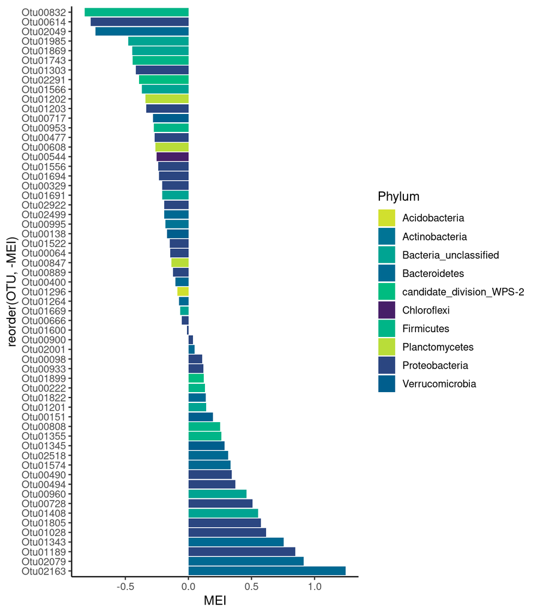

```r
ggplot(alf_OTUS, aes(x = reorder(OTU, -MEI), y = MEI, fill = Phylum)) +
  geom_bar(stat = "identity") + coord_flip() +
  scale_color_manual(aesthetics = "fill", values = colors) +
  theme_classic2()
```

## Plot comp responder OTUs’ MEI

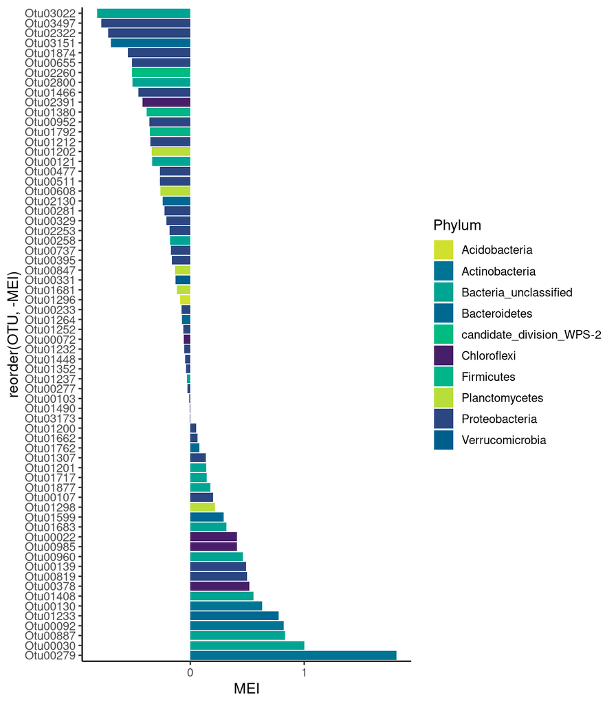

```r
ggplot(comp_OTUS, aes(x = reorder(OTU, -MEI), y = MEI, fill = Phylum)) +
  geom_bar(stat = "identity") + coord_flip() +
  scale_color_manual(aesthetics = "fill", values = colors) +
  theme_classic2()
```

## Plot mix responder OTUs’ MEI

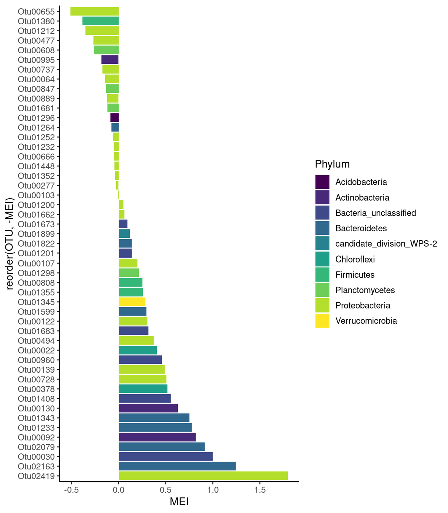

```r
ggplot(mix_OTUS, aes(x = reorder(OTU, -MEI), y = MEI, fill = Phylum)) +
  geom_bar(stat = "identity") + coord_flip() +
  scale_color_manual(aesthetics = "fill", values = colors) +
  theme_classic2() +
  scale_fill_viridis_d()
```

# Otu02419

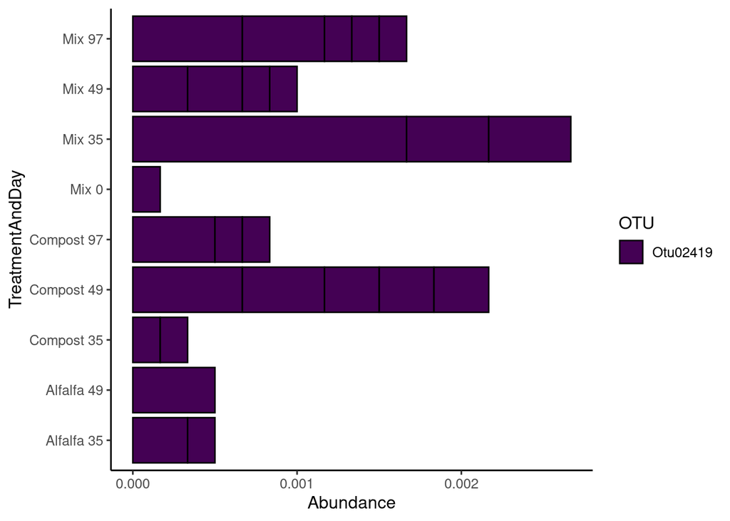

```r
library(phylosmith)
myTaxa = "Otu02419"
test <- inc %>%
  transform_sample_counts(function(x) {x/sum(x)}) %>%
  prune_taxa(taxa = myTaxa) %>%
  prune_samples(sample_sums(.) > .0000001, .)

plot_bar(test, fill = "OTU", x = "TreatmentAndDay") +
  theme_classic2() +
  coord_flip() +
  rotate_x_text(0) +
  scale_fill_viridis_d()
```

In this it appears that perhaps day 35 was creating the high MEI value for OTU 02419…the first plot i generated was a little misleading…not as strong as MEI as indicated?

Also note, that each bar is split into sections representative of a sample, for this experiment we had 12 replicates for each combination of treatment and day, this taxa was only detected in at most 5 out of 12 samples.

```r
myTaxa <- mix_OTUS %>%
  filter(MEI > 0) %>%
  select(OTU)

myTaxa
```

```
##         OTU
## 1  Otu00022
## 2  Otu00030
## 3  Otu00092
## 4  Otu00122
## 5  Otu00130
## 6  Otu00139
## 7  Otu00378
## 8  Otu00494
## 9  Otu00728
## 10 Otu00808
## 11 Otu01200
## 12 Otu01343
## 13 Otu01345
## 14 Otu01599
## 15 Otu01662
## 16 Otu01673
## 17 Otu01822
## 18 Otu01899
## 19 Otu02079
## 20 Otu02163
## 21 Otu00107
## 22 Otu00960
## 23 Otu01201
## 24 Otu01233
## 25 Otu01298
## 26 Otu01355
## 27 Otu01408
## 28 Otu01683
## 29 Otu02419
```

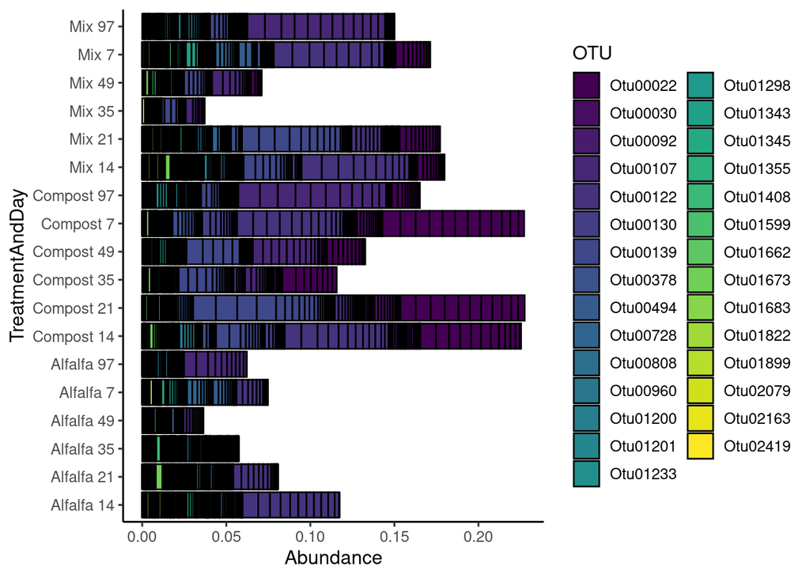

```r
test <- inc %>%
  subset_samples(treatment %in% c("Alfalfa", "Compost", "Mix") & day != 0) %>%
  transform_sample_counts(function(x) {x/sum(x)}) %>%
  prune_taxa(taxa = myTaxa$OTU) %>%
  prune_samples(sample_sums(.) > .0000001, .)

plot_bar(test, fill = "OTU", x = "TreatmentAndDay") +
  theme_classic2() +
  coord_flip() +
  rotate_x_text(0) +
  scale_fill_viridis_d()
```

# Otu00022

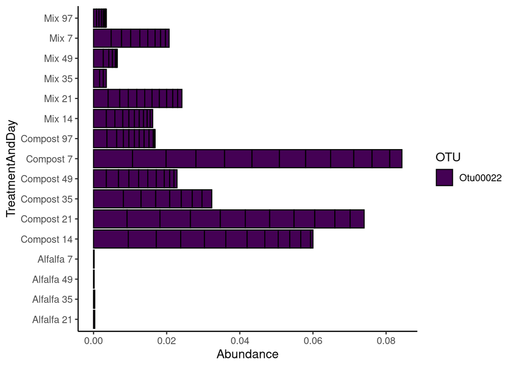

```r
myTaxa = "Otu00022"
test <- inc %>%
  subset_samples(treatment %in% c("Alfalfa", "Compost", "Mix") & day != 0) %>%
  transform_sample_counts(function(x) {x/sum(x)}) %>%
  prune_taxa(taxa = myTaxa) %>%
  prune_samples(sample_sums(.) > .0000001, .)

plot_bar(test, fill = "OTU", x = "TreatmentAndDay") +
  theme_classic2() +
  coord_flip() +
  rotate_x_text(0) +
  scale_fill_viridis_d()
```